# Project: Ford_Bike_Trip

- Introduction
- Data Wrangling
- Data Cleaning
- Univariate Exploration
- Bivariate Exploration
- Multivariate Exploration
- Conclusions

## Introduction

#### Ford GoBike is the Bay Area's new bike share system, with thousands of public bikes for use across San Francisco, East Bay and San Jose. Renting Bikes is designed with convenience in mind. it’s a fun and affordable way to get around town.It aslo offers Single Ride is 2 dollars per day which is great for one way trip, Monthly Memberships is 15 dollars per month for its good deal for locals and Access Pass for 10 dollars which is perfect for exploring.

## Importing necessary Libraries

```python
import pandas as pd

import numpy as np

import matplotlib.pyplot as plt

%matplotlib inline
```

```python
import seaborn as sns
```

```python
import os

import glob
```

```python
import warnings
warnings.filterwarnings('ignore')
```

```python
path = r'C:\Users\Thanniru Srinivas\Desktop\udacity\data analyst\project_5'
```

```python
files = glob.glob(os.path.join(path, "*.csv"))

data = pd.concat((pd.read_csv(f) for f in files), ignore_index = True)

data.to_csv('ford_go_bike_data.csv', index = False)
```

```python
bike_data = pd.read_csv('ford_go_bike_data.csv')
```

## Data Wrangling

```python
bike_data.head()
```

|  | duration_sec | start_time | end_time | start_station_id | start_station_name | start_station_latitude | start_station_longitude | end_station_id | end_station_name | end_station_latitude | end_station_longitude | bike_id | user_type | bike_share_for_all_trip |
| --- | --- | --- | --- | --- | --- | --- | --- | --- | --- | --- | --- | --- | --- | --- |
| 0 | 75284 | 2018-01-31 22:52:35.2390 | 2018-02-01 19:47:19.8240 | 120.0 | Mission Dolores Park | 37.761420 | -122.426435 | 285.0 | Webster St at O'Farrell St | 37.783521 | -122.431158 | 2765 | Subscriber | No |
| 1 | 85422 | 2018-01-31 16:13:34.3510 | 2018-02-01 15:57:17.3100 | 15.0 | San Francisco Ferry Building (Harry Bridges Pl... | 37.795392 | -122.394203 | 15.0 | San Francisco Ferry Building (Harry Bridges Pl... | 37.795392 | -122.394203 | 2815 | Customer | No |
| 2 | 71576 | 2018-01-31 14:23:55.8890 | 2018-02-01 10:16:52.1160 | 304.0 | Jackson St at 5th St | 37.348759 | -121.894798 | 296.0 | 5th St at Virginia St | 37.325998 | -121.877120 | 3039 | Customer | No |
| 3 | 61076 | 2018-01-31 14:53:23.5620 | 2018-02-01 07:51:20.5000 | 75.0 | Market St at Franklin St | 37.773793 | -122.421239 | 47.0 | 4th St at Harrison St | 37.780955 | -122.399749 | 321 | Customer | No |
| 4 | 39966 | 2018-01-31 19:52:24.6670 | 2018-02-01 06:58:31.0530 | 74.0 | Laguna St at Hayes St | 37.776435 | -122.426244 | 19.0 | Post St at Kearny St | 37.788975 | -122.403452 | 617 | Subscriber | No |

```python
bike_data.shape
```

```
(1863721, 14)
```

```python
bike_data.info()
```

```
<class 'pandas.core.frame.DataFrame'>
RangeIndex: 1863721 entries, 0 to 1863720
Data columns (total 14 columns):
 #   Column                   Dtype
---  ------                   -----
 0   duration_sec             int64
 1   start_time               object
 2   end_time                 object
 3   start_station_id         float64
 4   start_station_name       object
 5   start_station_latitude   float64
 6   start_station_longitude  float64
 7   end_station_id           float64
 8   end_station_name         object
 9   end_station_latitude     float64
 10  end_station_longitude    float64
 11  bike_id                  int64
 12  user_type                object
 13  bike_share_for_all_trip  object
dtypes: float64(6), int64(2), object(6)
memory usage: 199.1+ MB
```

```python
bike_data.isnull().sum()
```

```
duration_sec                   0
start_time                     0
end_time                       0
start_station_id           11771
start_station_name         11771
start_station_latitude         0
start_station_longitude        0
end_station_id             11771
end_station_name           11771
end_station_latitude           0
end_station_longitude          0
bike_id                        0
user_type                      0
bike_share_for_all_trip        0
dtype: int64
```

```python
bike_data.duplicated().sum()
```

```
0
```

```python
bike_data.describe()
```

|  | duration_sec | start_station_id | start_station_latitude | start_station_longitude | end_station_id | end_station_latitude | end_station_longitude | bike_id |
| --- | --- | --- | --- | --- | --- | --- | --- | --- |
| count | 1.863721e+06 | 1.851950e+06 | 1.863721e+06 | 1.863721e+06 | 1.851950e+06 | 1.863721e+06 | 1.863721e+06 | 1.863721e+06 |
| mean | 8.573026e+02 | 1.196744e+02 | 3.776678e+01 | -1.223492e+02 | 1.181730e+02 | 3.776690e+01 | -1.223487e+02 | 2.296851e+03 |
| std | 2.370379e+03 | 1.003976e+02 | 1.057689e-01 | 1.654634e-01 | 1.004403e+02 | 1.056483e-01 | 1.650597e-01 | 1.287733e+03 |
| min | 6.100000e+01 | 3.000000e+00 | 3.726331e+01 | -1.224737e+02 | 3.000000e+00 | 3.726331e+01 | -1.224737e+02 | 1.100000e+01 |
| 25% | 3.500000e+02 | 3.300000e+01 | 3.777106e+01 | -1.224114e+02 | 3.000000e+01 | 3.777106e+01 | -1.224094e+02 | 1.225000e+03 |
| 50% | 5.560000e+02 | 8.900000e+01 | 3.778107e+01 | -1.223974e+02 | 8.800000e+01 | 3.778127e+01 | -1.223971e+02 | 2.338000e+03 |
| 75% | 8.720000e+02 | 1.860000e+02 | 3.779625e+01 | -1.222865e+02 | 1.830000e+02 | 3.779728e+01 | -1.222894e+02 | 3.333000e+03 |
| max | 8.636600e+04 | 3.810000e+02 | 4.551000e+01 | -7.357000e+01 | 3.810000e+02 | 4.551000e+01 | -7.357000e+01 | 6.234000e+03 |

```python
bike_data.user_type.unique()
```

```
array(['Subscriber', 'Customer'], dtype=object)
```

```python
bike_data.bike_share_for_all_trip.unique()
```

```
array(['No', 'Yes'], dtype=object)
```

## Tidiness

##### 1) Extract day and month from start_time and end_time

## Data Cleaning

```python
bike_data_clean = bike_data.copy()
```

### Define

### Quality problem 1 - Drop rows having null values

### Code

```python
bike_data_clean.dropna(inplace = True)
```

### Test

```python
bike_data_clean.shape
```

```
(1851950, 14)
```

```python
bike_data_clean.isnull().sum()
```

```
duration_sec               0
start_time                 0
end_time                   0
start_station_id           0
start_station_name         0
start_station_latitude     0
start_station_longitude    0
end_station_id             0
end_station_name           0
end_station_latitude       0
end_station_longitude      0
bike_id                    0
user_type                  0
bike_share_for_all_trip    0
dtype: int64
```

### Define

### Quality problem 2 - Convert start_time and end_time to datetime

### Code

```python
bike_data_clean.start_time = pd.to_datetime(bike_data_clean.start_time)

bike_data_clean.end_time = pd.to_datetime(bike_data_clean.end_time)
```

### Test

```python
bike_data_clean.info()
```

```
<class 'pandas.core.frame.DataFrame'>
Int64Index: 1851950 entries, 0 to 1863720
Data columns (total 14 columns):
 #   Column                   Dtype
---  ------                   -----
 0   duration_sec             int64
 1   start_time               datetime64[ns]
 2   end_time                 datetime64[ns]
 3   start_station_id         float64
 4   start_station_name       object
 5   start_station_latitude   float64
 6   start_station_longitude  float64
 7   end_station_id           float64
 8   end_station_name         object
 9   end_station_latitude     float64
 10  end_station_longitude    float64
 11  bike_id                  int64
 12  user_type                object
 13  bike_share_for_all_trip  object
dtypes: datetime64[ns](2), float64(6), int64(2), object(4)
memory usage: 211.9+ MB
```

### Define

### Quality problem 3 - convert start_station_id , end_station_id and bike_id to object type

### Code

```python
bike_data_clean.start_station_id = bike_data_clean.start_station_id.astype(int)

bike_data_clean.end_station_id = bike_data_clean.end_station_id.astype(int)

bike_data_clean.bike_id = bike_data_clean.bike_id.astype(int)
```

```python
bike_data_clean.start_station_id = bike_data_clean.start_station_id.astype(str)

bike_data_clean.end_station_id = bike_data_clean.end_station_id.astype(str)

bike_data_clean.bike_id = bike_data_clean.bike_id.astype(str)
```

### Test

```python
bike_data_clean.info()
```

```
<class 'pandas.core.frame.DataFrame'>
Int64Index: 1851950 entries, 0 to 1863720
Data columns (total 14 columns):
 #   Column                   Dtype
---  ------                   -----
 0   duration_sec             int64
 1   start_time               datetime64[ns]
 2   end_time                 datetime64[ns]
 3   start_station_id         object
 4   start_station_name       object
 5   start_station_latitude   float64
 6   start_station_longitude  float64
 7   end_station_id           object
 8   end_station_name         object
 9   end_station_latitude     float64
 10  end_station_longitude    float64
 11  bike_id                  object
 12  user_type                object
 13  bike_share_for_all_trip  object
dtypes: datetime64[ns](2), float64(4), int64(1), object(7)
memory usage: 211.9+ MB
```

```python
bike_data_clean.head()
```

|  | duration_sec | start_time | end_time | start_station_id | start_station_name | start_station_latitude | start_station_longitude | end_station_id | end_station_name | end_station_latitude | end_station_longitude | bike_id | user_type | bike_share_for_all_trip |
| --- | --- | --- | --- | --- | --- | --- | --- | --- | --- | --- | --- | --- | --- | --- |
| 0 | 75284 | 2018-01-31 22:52:35.239 | 2018-02-01 19:47:19.824 | 120 | Mission Dolores Park | 37.761420 | -122.426435 | 285 | Webster St at O'Farrell St | 37.783521 | -122.431158 | 2765 | Subscriber | No |
| 1 | 85422 | 2018-01-31 16:13:34.351 | 2018-02-01 15:57:17.310 | 15 | San Francisco Ferry Building (Harry Bridges Pl... | 37.795392 | -122.394203 | 15 | San Francisco Ferry Building (Harry Bridges Pl... | 37.795392 | -122.394203 | 2815 | Customer | No |
| 2 | 71576 | 2018-01-31 14:23:55.889 | 2018-02-01 10:16:52.116 | 304 | Jackson St at 5th St | 37.348759 | -121.894798 | 296 | 5th St at Virginia St | 37.325998 | -121.877120 | 3039 | Customer | No |
| 3 | 61076 | 2018-01-31 14:53:23.562 | 2018-02-01 07:51:20.500 | 75 | Market St at Franklin St | 37.773793 | -122.421239 | 47 | 4th St at Harrison St | 37.780955 | -122.399749 | 321 | Customer | No |
| 4 | 39966 | 2018-01-31 19:52:24.667 | 2018-02-01 06:58:31.053 | 74 | Laguna St at Hayes St | 37.776435 | -122.426244 | 19 | Post St at Kearny St | 37.788975 | -122.403452 | 617 | Subscriber | No |

### Define

### Quality problem 4 - convert user_type and bike_share_for_all_trip to categorical type

### Code

```python
bike_data_clean.user_type = bike_data_clean.user_type.astype('category')

bike_data_clean.bike_share_for_all_trip = bike_data_clean.bike_share_for_all_trip.astype('category')
```

### Test

```python
bike_data_clean.info()
```

```
<class 'pandas.core.frame.DataFrame'>
Int64Index: 1851950 entries, 0 to 1863720
Data columns (total 14 columns):
 #   Column                   Dtype
---  ------                   -----
 0   duration_sec             int64
 1   start_time               datetime64[ns]
 2   end_time                 datetime64[ns]
 3   start_station_id         object
 4   start_station_name       object
 5   start_station_latitude   float64
 6   start_station_longitude  float64
 7   end_station_id           object
 8   end_station_name         object
 9   end_station_latitude     float64
 10  end_station_longitude    float64
 11  bike_id                  object
 12  user_type                category
 13  bike_share_for_all_trip  category
dtypes: category(2), datetime64[ns](2), float64(4), int64(1), object(5)
memory usage: 187.2+ MB
```

### Define

### Tidiness problem - Extract day and month from start_time and end_time

### code

```python
bike_data_clean['start_time_day'] = bike_data_clean['start_time'].dt.day.astype(int)

bike_data_clean['start_time_month'] = bike_data_clean['start_time'].dt.month.astype(int)
```

```python
bike_data_clean['end_time_day'] = bike_data_clean['end_time'].dt.day.astype(int)

bike_data_clean['end_time_month'] = bike_data_clean['end_time'].dt.month.astype(int)
```

### Test

```python
bike_data_clean.info()
```

```
<class 'pandas.core.frame.DataFrame'>
Int64Index: 1851950 entries, 0 to 1863720
Data columns (total 18 columns):
 #   Column                   Dtype
---  ------                   -----
 0   duration_sec             int64
 1   start_time               datetime64[ns]
 2   end_time                 datetime64[ns]
 3   start_station_id         object
 4   start_station_name       object
 5   start_station_latitude   float64
 6   start_station_longitude  float64
 7   end_station_id           object
 8   end_station_name         object
 9   end_station_latitude     float64
 10  end_station_longitude    float64
 11  bike_id                  object
 12  user_type                category
 13  bike_share_for_all_trip  category
 14  start_time_day           int32
 15  start_time_month         int32
 16  end_time_day             int32
 17  end_time_month           int32
dtypes: category(2), datetime64[ns](2), float64(4), int32(4), int64(1), object(5)
memory usage: 215.5+ MB
```

```python
bike_data_clean.head()
```

|  | duration_sec | start_time | end_time | start_station_id | start_station_name | start_station_latitude | start_station_longitude | end_station_id | end_station_name | end_station_latitude | end_station_longitude | bike_id | user_type | bike_share_for_all_trip | start_time_day | start_time_month | end_time_day | end_time_month |
| --- | --- | --- | --- | --- | --- | --- | --- | --- | --- | --- | --- | --- | --- | --- | --- | --- | --- | --- |
| 0 | 75284 | 2018-01-31 22:52:35.239 | 2018-02-01 19:47:19.824 | 120 | Mission Dolores Park | 37.761420 | -122.426435 | 285 | Webster St at O'Farrell St | 37.783521 | -122.431158 | 2765 | Subscriber | No | 31 | 1 | 1 | 2 |
| 1 | 85422 | 2018-01-31 16:13:34.351 | 2018-02-01 15:57:17.310 | 15 | San Francisco Ferry Building (Harry Bridges Pl... | 37.795392 | -122.394203 | 15 | San Francisco Ferry Building (Harry Bridges Pl... | 37.795392 | -122.394203 | 2815 | Customer | No | 31 | 1 | 1 | 2 |
| 2 | 71576 | 2018-01-31 14:23:55.889 | 2018-02-01 10:16:52.116 | 304 | Jackson St at 5th St | 37.348759 | -121.894798 | 296 | 5th St at Virginia St | 37.325998 | -121.877120 | 3039 | Customer | No | 31 | 1 | 1 | 2 |
| 3 | 61076 | 2018-01-31 14:53:23.562 | 2018-02-01 07:51:20.500 | 75 | Market St at Franklin St | 37.773793 | -122.421239 | 47 | 4th St at Harrison St | 37.780955 | -122.399749 | 321 | Customer | No | 31 | 1 | 1 | 2 |
| 4 | 39966 | 2018-01-31 19:52:24.667 | 2018-02-01 06:58:31.053 | 74 | Laguna St at Hayes St | 37.776435 | -122.426244 | 19 | Post St at Kearny St | 37.788975 | -122.403452 | 617 | Subscriber | No | 31 | 1 | 1 | 2 |

# Univariate Exploration

## Count of Subscribers vs Customers

```python
subscriber = bike_data_clean.query('user_type == "Subscriber"').shape[0]
```

```python
customer = bike_data_clean.query('user_type == "Customer"').shape[0]
```

```python
bike_data_clean.shape[0] == customer + subscriber
```

```
True
```

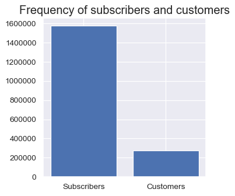

```python
plt.figure(figsize=(4,4),dpi=90)
# we are plotting the figure by specifying the figure size and resolution

plt.bar(x = ['Subscribers','Customers'] , height = [subscriber ,customer ])
# we are plotting the bar graph

plt.title('Frequency of subscribers and customers' , fontsize = 16)
# Title for the graph
```

#### We see that most of the people who took bike rides are subscribers.

## Duration of rides

```python
bike_data_clean.duration_sec
```

```
0          75284
1          85422
2          71576
3          61076
4          39966
           ...
1863716      473
1863717      841
1863718      260
1863719      292
1863720      150
Name: duration_sec, Length: 1851950, dtype: int64
```

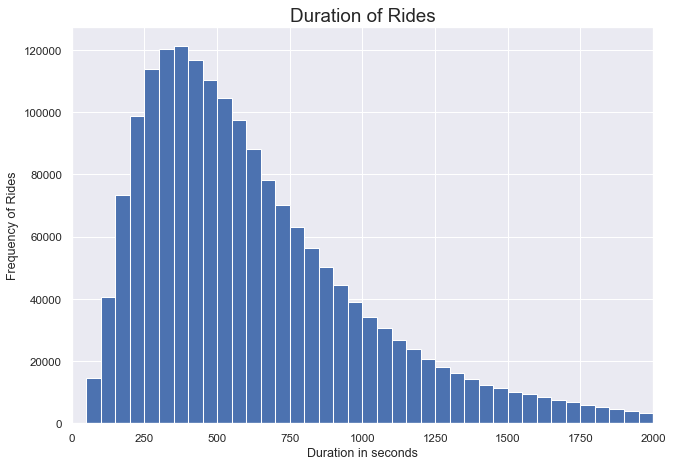

```python
plt.figure(figsize=(10,7),dpi=75)
# we are plotting the figure by specifying the figure size and resolution

duration_bins = np.arange(0,bike_data_clean['duration_sec'].max()+50 , 50);
# Set the bins at the respective interval i.e 50 units here

plt.hist(data = bike_data_clean , x ='duration_sec' , bins = duration_bins );
# we are plotting the histogram

plt.xlim(0,2000);
# Limit the graph portion till 2000 sec

plt.title('Duration of Rides' , fontsize = 18);
# Title for the graph

plt.xlabel('Duration in seconds' , fontsize = 12);
# Label on x-axis

plt.ylabel('Frequency of Rides' , fontsize = 12);
# label on y-axis
```

#### We observe that most of the rides are having the duration within 1000 seconds.

#### The distribution of the above graph is right skewed.

## Sharing bike during the Trip

```python
bike_share = bike_data_clean.bike_share_for_all_trip.value_counts()
```

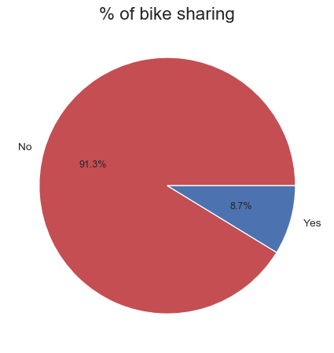

```python
plt.figure(figsize = (8,6), dpi =90)
# we are plotting the figure by specifying the figure size and resolution

plt.title('% of bike sharing',fontsize=18);
# title for the graph

colors = ['r','b']
# setting the color for each portion of the piechart

plt.pie(bike_share.values,labels=bike_share.index,colors = colors,autopct = '%1.1f%%');
# plotting piechart  with respective color for their portion
```

#### We see that 91.3% of the users did not share the bike during trip while 8.7% of the users have shared the bike.

# Bivariate Exploration

```python
bike_data_clean.head()
```

|  | duration_sec | start_time | end_time | start_station_id | start_station_name | start_station_latitude | start_station_longitude | end_station_id | end_station_name | end_station_latitude | end_station_longitude | bike_id | user_type | bike_share_for_all_trip | start_time_day | start_time_month | end_time_day | end_time_month |
| --- | --- | --- | --- | --- | --- | --- | --- | --- | --- | --- | --- | --- | --- | --- | --- | --- | --- | --- |
| 0 | 75284 | 2018-01-31 22:52:35.239 | 2018-02-01 19:47:19.824 | 120 | Mission Dolores Park | 37.761420 | -122.426435 | 285 | Webster St at O'Farrell St | 37.783521 | -122.431158 | 2765 | Subscriber | No | 31 | 1 | 1 | 2 |
| 1 | 85422 | 2018-01-31 16:13:34.351 | 2018-02-01 15:57:17.310 | 15 | San Francisco Ferry Building (Harry Bridges Pl... | 37.795392 | -122.394203 | 15 | San Francisco Ferry Building (Harry Bridges Pl... | 37.795392 | -122.394203 | 2815 | Customer | No | 31 | 1 | 1 | 2 |
| 2 | 71576 | 2018-01-31 14:23:55.889 | 2018-02-01 10:16:52.116 | 304 | Jackson St at 5th St | 37.348759 | -121.894798 | 296 | 5th St at Virginia St | 37.325998 | -121.877120 | 3039 | Customer | No | 31 | 1 | 1 | 2 |
| 3 | 61076 | 2018-01-31 14:53:23.562 | 2018-02-01 07:51:20.500 | 75 | Market St at Franklin St | 37.773793 | -122.421239 | 47 | 4th St at Harrison St | 37.780955 | -122.399749 | 321 | Customer | No | 31 | 1 | 1 | 2 |
| 4 | 39966 | 2018-01-31 19:52:24.667 | 2018-02-01 06:58:31.053 | 74 | Laguna St at Hayes St | 37.776435 | -122.426244 | 19 | Post St at Kearny St | 37.788975 | -122.403452 | 617 | Subscriber | No | 31 | 1 | 1 | 2 |

## Number of bike rides Vs Month

```python
rides_per_month  = bike_data_clean.groupby('start_time_month')['bike_id'].count()
```

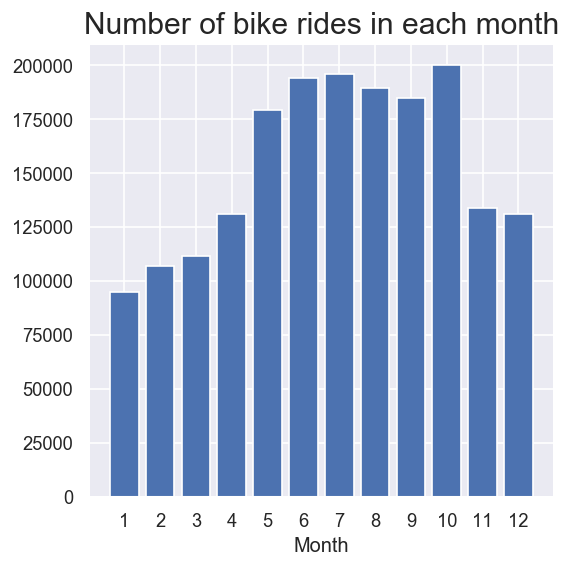

```python
plt.figure(figsize=(5,5),dpi=120)
# we are plotting the figure by specifying the figure size and resolution

plt.xlabel('Month', fontsize = 12)
# we are setting the label for x-axis  using specified  fontsize

plt.title('Number of bike rides in each month',fontsize=18)
# we are specifying the name for the title of the graph

plt.bar(np.arange(1,13),rides_per_month);
# we are plotting the bar graph

plt.xticks(np.arange(1,13));
# setting the tick labels for the x-axis
```

#### We see that most number of rides were taken in the month of October while least number of rides were taken in the month of January

## Monthly Bike rides vs User_types

```python
monthly_user_types = bike_data_clean.groupby(['start_time_month' , 'user_type']).size().reset_index()
```

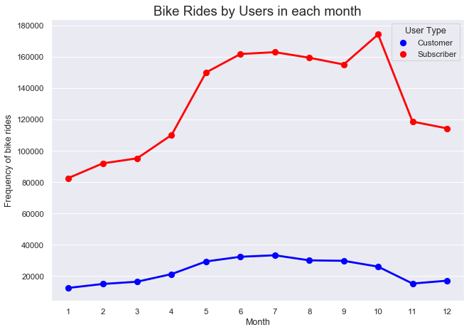

```python
plt.figure(figsize=(10,7),dpi = 75)
# we are plotting the figure by specifying the figure size and resolution

colors = {'Subscriber' : 'Red' , 'Customer' : 'Blue'}
# colors for user_types

ax = sns.pointplot(x='start_time_month',y = 0, hue = 'user_type' , palette = colors , data = monthly_user_types)
# here we are plotting pointplot

plt.title('Bike Rides by Users in each month' , fontsize = 18)
# Title for the graph

plt.xlabel('Month' , fontsize = 12)
# Label on x-axis

plt.ylabel('Frequency of bike rides' , fontsize = 12)
# Label on y-axis

ax.legend().set_title('User Type')
# Title for the legend
```

#### 1) We see that most number of rides taken by Customers were in the month of July while least number of rides were taken in the month of January.

#### 2) We see that most number of rides taken by Subscribers were in the month of October while least number of rides were taken in the month of January.

## Average Duration of Rides vs Users type

```python
average_duration = bike_data_clean.groupby('user_type')['duration_sec'].mean()
```

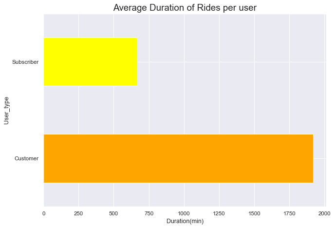

```python
plt.figure(figsize=(10,7),dpi = 75)
# we are plotting the figure by specifying the figure size and resolution

colors = ['orange' , 'yellow']
# colors for user_types

average_duration.plot(kind = 'barh' , color = colors);
# Here we are plotting bar-horizontal graph

plt.title('Average Duration of Rides per user' , fontsize = 18)
# Title for the graph

plt.xlabel('Duration(min)' , fontsize = 12)
# Label on x-axis

plt.ylabel('User_type' , fontsize = 12)
# Label on y-axis
```

#### We see that the customers have made more longer trips than subscribers .

# Multivariate Exploration

## Day vs Month Vs Subscriber

```python
subscriber = bike_data_clean.query('user_type == "Subscriber"').groupby(['start_time_month','start_time_day']).agg({'bike_id'
             : 'count'}).rename(columns={'bike_id':'count'}).reset_index()
```

```python
subscriber_pivot = subscriber.pivot_table(index = 'start_time_day' , columns = 'start_time_month' , values = 'count')
```

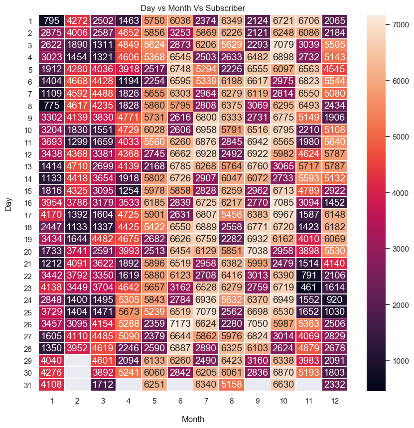

```python
plt.figure(figsize = (10,10) ,dpi =100 )

sns.heatmap(subscriber_pivot,  annot=True, fmt='.0f',linewidths = .5 , annot_kws={"size": 14} );

plt.title('Day vs Month Vs Subscriber')

plt.xlabel('Month', labelpad=16)

plt.ylabel('Day', labelpad=16)

plt.yticks(rotation=0)
```

#### We see that most of the subscribers made bike rides on 26th of June 2018 i.e. 7173 bike rides

## Day vs Month Vs Customer

```python
customer = bike_data_clean.query('user_type == "Customer"').groupby(['start_time_month','start_time_day']).agg({'bike_id'
             : 'count'}).rename(columns={'bike_id':'count'}).reset_index()
```

```python
customer['count'].max()
```

```
1732
```

```python
customer_pivot = customer.pivot_table(index = 'start_time_day' , columns = 'start_time_month' , values = 'count')
```

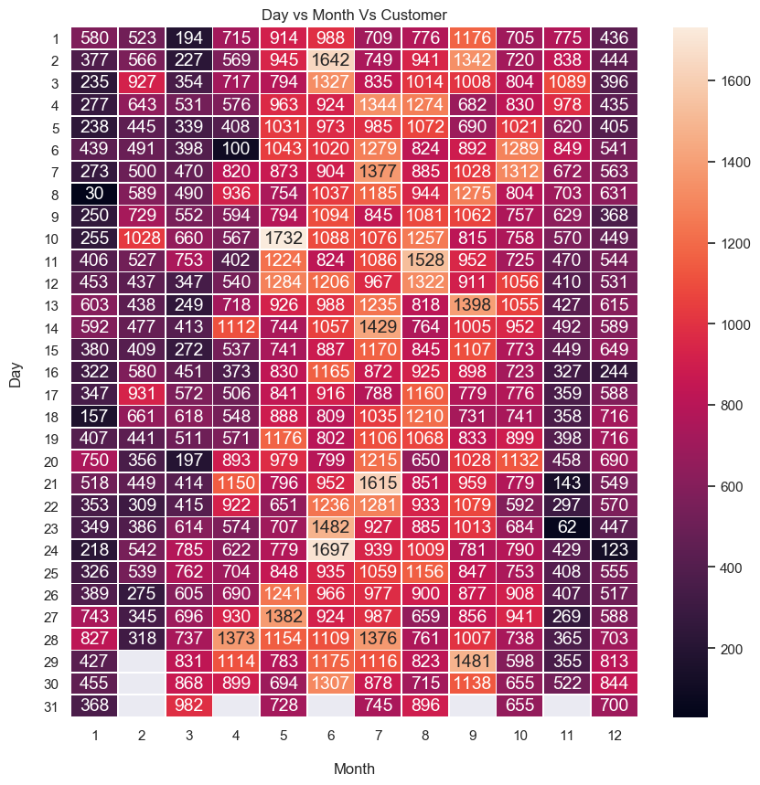

```python
plt.figure(figsize = (10,10) ,dpi =100 )

sns.heatmap(customer_pivot,  annot=True, fmt='.0f',linewidths = .5 , annot_kws={"size": 14} );

plt.title('Day vs Month Vs Customer')

plt.xlabel('Month', labelpad=16)

plt.ylabel('Day', labelpad=16)

plt.yticks(rotation=0)
```

## References

https://pandas.pydata.org/docs/getting_started/tutorials.html

https://seaborn.pydata.org/

https://medium.com/

https://towardsdatascience.com/

https://www.thetopsites.net/article/52111511.shtml

https://stackoverflow.com/questions/5627605/string-formatting-with-0d-format-gives-unknown-format-code-d-for-object-o